# Session 5 — Choosing, Checking and Reporting

Decision guide · diagnostics · few clusters · sample size for cluster trials · reporting · Lab 5

Community Medicine Workshop

## Where we are

- Sessions 1 to 4: ICC, design effect, robust SEs, GEE, mixed models, repeated measures
- Today: **which one to use**, how to **check** it, how to **plan** a cluster trial and how to **report** it

# Topic 1 — Choosing

## Decision guide

| Situation | Suggested approach |
| --- | --- |
| Few clusters (below about 10) | **Cluster-level** analysis (means, permutation); avoid model-based |
| 10 to 40 clusters | **Mixed model** with Satterthwaite/Kenward-Roger df, or **CR2** |
| Many clusters, marginal effect wanted | **GEE** or cluster-robust `glm` |
| Cluster effects of interest, predictions | **Mixed model** |
| Repeated measures, missing visits | **Mixed model** (MAR) |
| Binary outcome, population-averaged OR | **GEE** |
| Binary outcome, within-cluster OR | **Mixed logistic** (`glmer`) |

## One table of the approaches

```r
m_lm <- lm(sbp ~ arm + age + sex + bmi, data = bp12)
m_mx <- lmer(sbp ~ arm + age + sex + bmi + (1 | village), data = bp12)
tibble(method = c("naive lm", "cluster-robust lm", "mixed model"),
       estimate = c(coef(m_lm)[["armProgramme"]], coef(m_lm)[["armProgramme"]], fixef(m_mx)[["armProgramme"]]),
       se = c(summary(m_lm)$coefficients["armProgramme", 2], coeftest(m_lm, vcov = vcovCL(m_lm, cluster = bp12$village))["armProgramme", 2], summary(m_mx)$coefficients["armProgramme", 2])) |>
  mutate(across(where(is.numeric), \(x) round(x, 2)))
```

```
# A tibble: 3 × 3
  method            estimate    se
  <chr>                <dbl> <dbl>
1 naive lm             -3.42  1.15
2 cluster-robust lm    -3.42  1.59
3 mixed model          -3.57  1.6
```

Report the **honest SE** (cluster-robust or mixed). If someone shows you a clustered analysis with the **naive SE** of 1.15, the result looks **more significant than it is**.

# Topic 2 — Checking

## Residuals and random effects

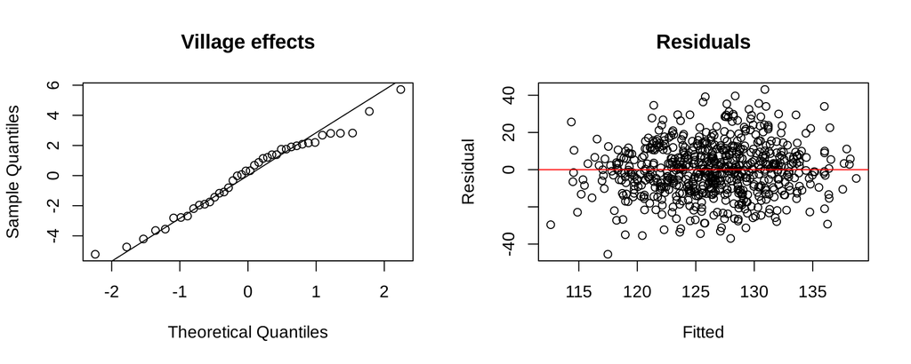

```r
par(mfrow = c(1, 2))
qqnorm(ranef(m_mx)$village[, 1], main = "Village effects"); qqline(ranef(m_mx)$village[, 1])
plot(fitted(m_mx), resid(m_mx), xlab = "Fitted", ylab = "Residual", main = "Residuals"); abline(h = 0, col = "red")
```

- **Village effects** roughly on the line: normality is plausible. With 40 villages the check is rough
- **Residuals**: even band, no funnel
- Mixed models are **fairly robust** to the shape of random effects; they are **not** robust to wrong **mean** or **correlation** structures

## Common problems

- **Singular fit** or non-convergence: too complex (random slopes with few visits): **simplify**
- **Few clusters**: SEs and df unreliable
- **Cluster-level covariates** with few clusters: low power whatever the number of people
- **Treating repeated measures as independent**: the commonest mistake

# Topic 3 — Planning and reporting

## Sample size for a cluster trial

n<sub>cluster</sub> = n<sub>individual</sub> × [ 1 + (m − 1) × ICC ]

```r
300 * (1 + (25 - 1) * 0.07)
```

```
[1] 804
```

```r
ceiling(804 / 25)
```

```
[1] 33
```

- 300 per arm if individually randomised, **25 per village**, ICC 0.07: about **804 people** (**33 villages**) per arm
- More **people per village** gives **diminishing returns**; more **villages** helps more
- Take the ICC from **earlier studies** and test a range

## Reporting a clustered analysis

- Follow the **CONSORT extension for cluster trials**: number of clusters per arm, mean cluster size, **ICC**
- State **how clustering was handled** (mixed model, GEE, cluster-robust, cluster means)
- Give **effect, 95% CI**, and the **df method** if few clusters
- Say whether the effect is **conditional or marginal** for binary outcomes
- Describe how **missing visits** were handled

*Example:* “At 12 months, the programme lowered SBP by 3.6 mmHg (95% CI −6.7 to −0.4), estimated with a linear mixed model with a random intercept for village (40 villages; ICC 0.06).”

## 🔧 Switch to R — Lab 5

**File:** `clustered-workshop/labs/lab5_report.R`

- compare the approaches in one table
- sample size for a cluster trial
- model checks and a one-sentence result

**Time:** 35 minutes · answer the Q questions in the comments

## Self-check quiz (1/5)

You have 8 villages in a cluster-randomised trial. What is the safest approach?

- Fit a cluster-robust lm and report its standard errors without a correction
- Treat the 160 adults as independent observations after adjusting for age
- Use a GEE with an unstructured working correlation matrix and robust SEs
- Analyse the village means, for example with a permutation test between arms

## Self-check quiz (2/5)

Why does adding more people per village help less than adding more villages?

- Extra people in a village add little, since they share its information
- Villages contain more information than the individual people who live in them
- Increasing the number of people per village raises the ICC in a linear way
- Extra people can be used in a GEE, but a mixed model cannot use them

## Self-check quiz (3/5)

A trial needs 400 per arm if individually randomised. With 20 per cluster and ICC 0.05, about how many per arm are needed?

- About 400
- About 420
- About 780
- About 8,000

## Self-check quiz (4/5)

Which information should a cluster-randomised trial report according to CONSORT for cluster trials?

- The total number of people who took part in the whole trial
- The number of clusters per arm, the cluster sizes and the ICC
- The p-value of the random intercept test, reported on its own
- The names of the villages that were put in each of the arms

## Self-check quiz (5/5)

Which mistake is the most common with repeated measures data?

- Using a model with a random intercept for each person followed in the study
- Plotting the mean trajectory of each group against time since baseline
- Treating visits as independent observations in a regression model
- Keeping the data in long format, with one row for each visit made

## Score and take-home

- **Few clusters** → cluster-level analysis or small-sample corrections
- Check **residuals** and **random effects**; simplify if singular
- **Sample size** = individual n × DEFF; **more clusters** beat bigger clusters
- Report **clusters, cluster size, ICC**, the method and the **CI**
- Never treat repeated measures as independent

**Next:** Cheat sheet and the next module